# Investigating missing data using areal-level estimates

Terry Lines, University of Glasgow

25/06/2021

## Introduction

Missing data, defined broadly as missing observations, imprecise measurements, and indirect observations of variables, are increasingly important when analysing datasets. This is due in part to datasets arising as volunteered information or as an observational byproduct of digitised transactions (Hand 2018), however designed surveys also suffer through declining response rates (Council and others 2013).

The value of geographic information in adjusting for unit non-response is recognised, as noted in comparisons between telephone-based sampling (random-digit-dialing), and addressed-based sampling (Battaglia et al. 2016). Auxiliary data is available both at an areal level (e.g. small area census data) and address specific (e.g. nature of address and any available geocoding matched information). The information can be used to to reduce non-response bias by calibrating sample aggregates against against the small area statistics (Lundström and Särndal 1999), assigning attributes based on the areal information (Biemer and Peytchev 2013), or generating a response propensity model to predict response rates and adjust sampling plans accordingly (Bradley et al. 2015).

Item non-response (where a survey participant has provided a partial response) can also be corrected for, using a framework introduced by Rubin (Rubin 1976), with solutions for imputing missing values such as expectation maximisation and multiple imputation techniques (Little and Rubin 2019). This is normally undertaken assuming an aspatial relationship, however, these techniques have been extended to spatial autoregressive models considering “Missing at Random” data (Kelejian and Prucha 2010; LeSage and Pace 2004), as well as “Missing Not at Random” data through using a selection (Heckman) spatial autoregression model (Flores-Lagunes and Schnier 2012; Geniaux and Martinetti 2016).

In this work we consider “Missing Not at Random” item non-response, where a survey participant has answered questions with the exception of a sensitive outcome, e.g. their level of income, where a “prefer not to answer” was recorded, and we believe the propensity to respond is linked to the unrecorded value. We wish to impute the outcome in order to use it in further analysis.

## Objective

The objective of this work is to analyse a pattern of item non-response in a survey with participant location, to consider:

1. whether there is a spatial structure in the patterns of missingness;
2. whether the missingness is Not At Random. We consider both imputed values and areal-level estimates to approximate the missing data;
3. how estimates are affected by accounting for spatial autocorrelation.

## Dataset

The UK National Travel Survey (NTS) will be used. The National Travel Survey is a household survey of personal travel within Great Britain, from data collected via interviews and a seven-day travel diary, which enables analysis of patterns and trends. Since 1988 it has been conducted on a continual basis, with around 15,000 households surveyed each year (since 2002 when sample size was increased). The rationale for using this survey is that it contains comprehensive demographic information for the participants including geography of the home address. Furthermore, because the demographic information is not the primary focus of the survey, item non-response, where participants declined to answer a question, was recorded in the survey without invalidating the response.

The open access version of the dataset bands key variables at a high-level, and provides location only at a regional level. However, for this work access was available under special licence to a safeguarded version for this project, which provides more detailed demographic information and address at a ward-level spatial resolution (an average of around 5,000 people per ward). The dataset covers all survey data from 2002 to 2019.

## Methodology and Results

The variable of missingness being investigated is whether or not a question on household income was answered by the Household Reference Person (the nominal head of household for the purposes of hte survey). This will be regressed across over household level survey data. The size of the dataset is 149,743 observations across 432 variables. These variables include address type information, accessibility of public transport, access to amenities, household vehicle access, household composition and household socio-economic information.

### Spatial structure

The overall proportion of missing income data is 22%. To initially examine spatial structure, the proportions of missingness are aggregated at a Unitary Authority level, as plotted below. The first graph shows the observed proportions for each UA. The second shows the z-statistic for that observed proportion, assuming a null model for the logistic regression. i.e a binomial distribution for missingness, with the same probability of missingness for each participant (estimated as the overall proportion of missingness). The model obviously doesn’t fit well - there are large residuals and patterns indicate underestimation in urban areas and over-estimation in rural areas.

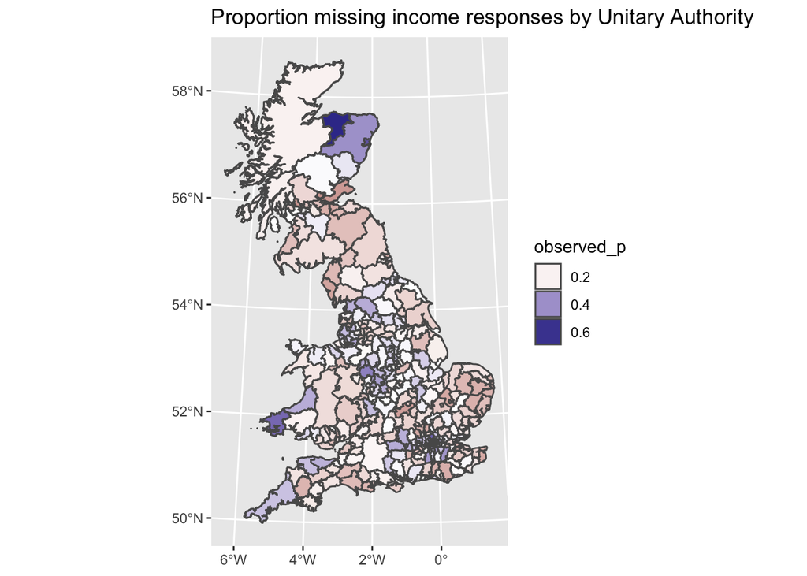

```r
#aggregate data at a UA level
UA_df <-   data.reduced %>% group_by(UA) %>% summarise(missing=sum(imputed),
                                                       count=n(),
                                                       observed_p=missing/count,
                                                       est_p=mean(data.reduced$imputed),
            ) %>%
  rowwise() %>% mutate(p_value=binom.test(missing,count,est_p,"less") %>% {.$p.value},z=p_value%>% max(1e-16) %>% min(1-1e-16) %>% qnorm())

UA_df <- UA_geo %>% inner_join(UA_df,by=c('LAD16CD'='UA')) %>% rename(UA=LAD16CD)
ggplot(UA_df)+geom_sf(aes(fill=observed_p))+scale_fill_gradient2(midpoint = mean(data.reduced$imputed))+ theme(legend.position = "right")+guides(fill = "legend")+labs(title='Proportion missing income responses by Unitary Authority')
```

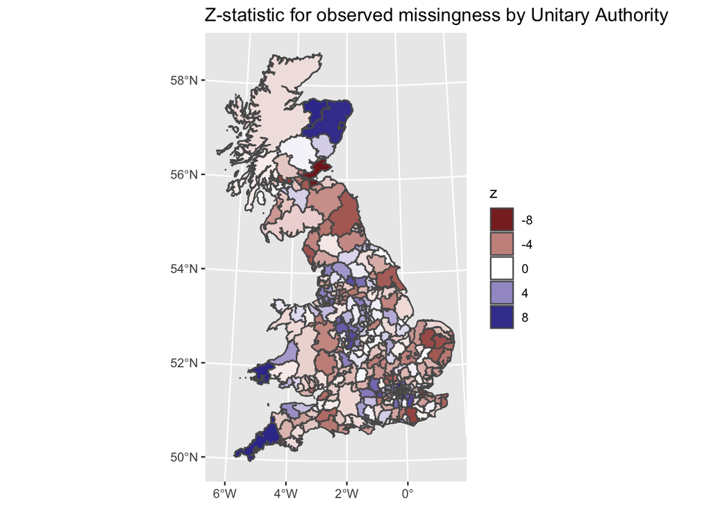

```r
ggplot(UA_df)+geom_sf(aes(fill=z))+scale_fill_gradient2()+ theme(legend.position = "right")+guides(fill = "legend")+labs(title='Z-statistic for observed missingness by Unitary Authority')
```

### Testing Missing At Randomness To test whether household income is Missing Not At Random, missingness must be regressed against income. Household income is available for all households in the survey: either directly if answered, otherwise it has been imputed as part of the survey data processing. The model specification for imputing income is not shared, but we presume it assumes a MAR distribution, which may be unreliable for parameter estimation if that assumption does not hold, which is our belief.

In order to have an alternative unbiased approximation of household income, we make use of location by associating households with areal mean income estimates. We use the [Office of National Statistics small area income estimates](https://www.ons.gov.uk/employmentandlabourmarket/peopleinwork/earningsandworkinghours/datasets/smallareaincomeestimatesformiddlelayersuperoutputareasenglandandwales). This provides mean income estimates at a middle layer super output area (MSOA) level. The estimates have been produced primarily through using the Family Resources Survey and performing a hierarchical regression with areal-level attributes generating an areal mean income estimate followed by an individual level regression performed using the areal mean. Further details are located in the technical report. It should be noted that the majority of the variance is at the individual level, and that the regression is undertake against Log(income) to deal with the skewed distribution of income.

There is a loose correlation between survey household income and areal level income. Note that Household income provided in the survey is banded, and the midpoints of the band ranges have been used.

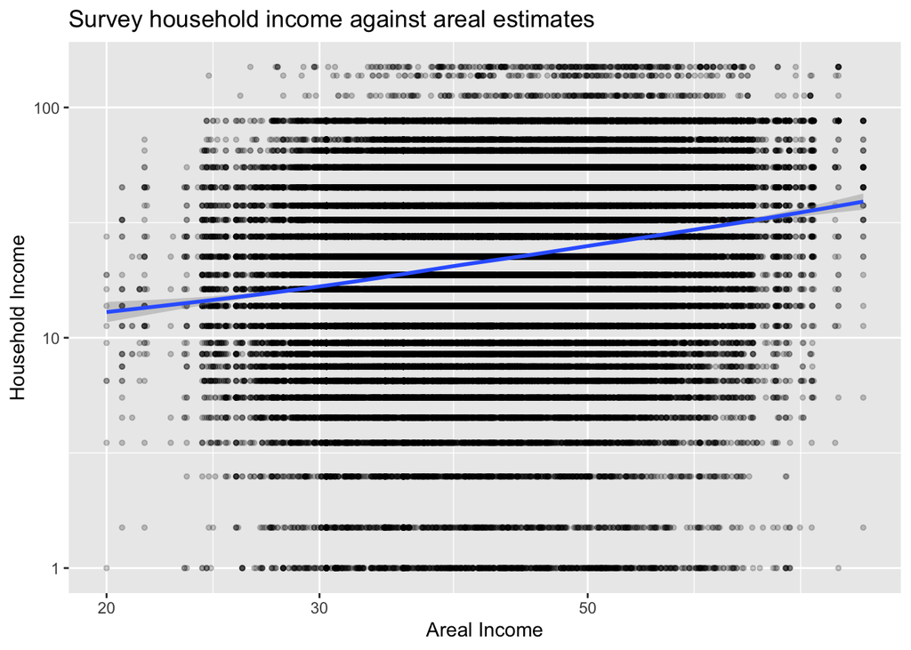

```r
lm(HHincome~income,data=data.recoded) %>% summary()
```

```
##
## Call:
## lm(formula = HHincome ~ income, data = data.recoded)
##
## Residuals:
##     Min      1Q  Median      3Q     Max
## -53.595 -17.660  -6.355  12.011 128.497
##
## Coefficients:
##             Estimate Std. Error t value Pr(>|t|)
## (Intercept) 6.323919   0.334498   18.91   <2e-16 ***
## income      0.577161   0.007676   75.19   <2e-16 ***
## ---
## Signif. codes:  0 '***' 0.001 '**' 0.01 '*' 0.05 '.' 0.1 ' ' 1
##
## Residual standard error: 24.29 on 101283 degrees of freedom
## Multiple R-squared:  0.05287,    Adjusted R-squared:  0.05286
## F-statistic:  5654 on 1 and 101283 DF,  p-value: < 2.2e-16
```

A model building process generates a plausible logistic model (the main effects model) for the imputation process. Full details of the process are included in Appendix 1. The main purpose of the model is to determine confounding factors for a regression of income against missingness. The fitted coefficients for income are compared for four possible models: a full model, which includes c.40 variables shortlisted for inclusion, a main model as mentioned above, a reduced model which varies the main model by excluding a classifier for region, and a univariate model based solely on income.

```r
models <- list(uni.model=uni.model,reduced.model=reduced.model,main.model=main.model,full.model=full.model,uni.model.hh=uni.model.hh,reduced.model.hh=reduced.model.hh,main.model.hh=main.model.hh,full.model.hh=full.model.hh)
model_comparison <- models %>% map_dfr(~broom::tidy(.x) %>% filter(term=='log(income)' |term=='log(HHincome)' )) %>% mutate(name=names(models)) %>% dplyr::select(name,!term)
model_comparison
```

```
## # A tibble: 8 x 5
##   name             estimate std.error statistic  p.value
##   <chr>               <dbl>     <dbl>     <dbl>    <dbl>
## 1 uni.model          0.432    0.0338      12.8  1.55e-37
## 2 reduced.model      0.420    0.0349      12.0  2.36e-33
## 3 main.model         0.0787   0.0403       1.95 5.10e- 2
## 4 full.model         0.180    0.0443       4.06 4.91e- 5
## 5 uni.model.hh       0.0318   0.00840      3.79 1.50e- 4
## 6 reduced.model.hh   0.0496   0.0111       4.47 7.88e- 6
## 7 main.model.hh      0.0445   0.0111       4.01 6.03e- 5
## 8 full.model.hh      0.0575   0.0121       4.76 1.89e- 6
```

### Examining the regression model for spatial correlation.

Having generated an aspatial logistic model it is examined for any spatial dependency in the outcomes. Similar to the initial anlysis of spatial structure, the observations are grouped by unitary authority (UA) and observed missingness compared to model predictions, generating residuals as p-values to a binomial test, and corresponding z-values. The UA-level observations are then tested for global spatial correlation.

```r
#Aggregate to a UA level
UA_df <-   main.model %>% predict(type='response') %>% {bind_cols(est_p=.,data %>% dplyr::select(code2016,UA,imputed))} %>%
  group_by(UA) %>%
  summarise(missing=sum(imputed),
            count=n(),
            expected_missing=sum(est_p),
            observed=count-missing,
            est_p=expected_missing/count,
            observed_p=missing/count) %>%
  rowwise() %>% mutate(p_value=binom.test(missing,count,est_p,"less") %>% {.$p.value},z=p_value%>% max(1e-16) %>% min(1-1e-16) %>% qnorm())

UA_df <- UA_geo %>% left_join(UA_df,by=c('LAD16CD'='UA'))
UA_df[is.na(UA_df$z),'z']=0
nb <- poly2nb(UA_df)
lw <- spdep::nb2listw(nb,style="C",zero.policy = TRUE)
```

A Moran plot and Moran’s I test strongly indicate spatial autocorrelation is present.

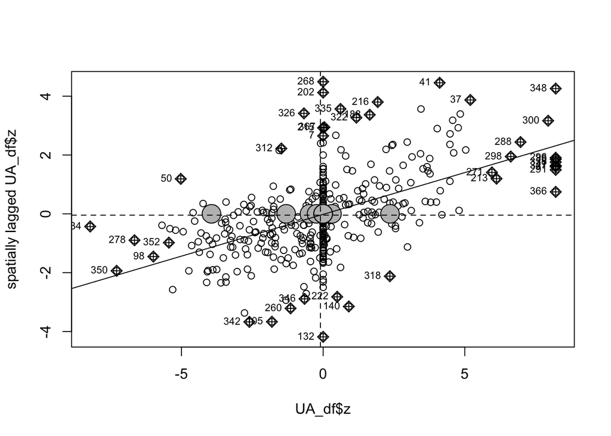

```r
moran.plot(UA_df$z,lw,zero.policy = TRUE)
```

```r
moran.test(UA_df$z,lw,zero.policy = TRUE)
```

```
##
##  Moran I test under randomisation
##
## data:  UA_df$z
## weights: lw  n reduced by no-neighbour observations
##
##
## Moran I statistic standard deviate = 8.8999, p-value < 2.2e-16
## alternative hypothesis: greater
## sample estimates:
## Moran I statistic       Expectation          Variance
##       0.284742565      -0.002680965       0.001042986
```

A SAR model is fit to the data, with the effect of lowering the estimated income coefficient further towards zero. All coefficients are relatively stable to the introduction of the saptial term.

```r
data_geo <- UA_geo %>% left_join(data %>% st_drop_geometry(),by=c('LAD16CD'='UA')) %>% rename(UA=LAD16CD)
main.model.sar <- fitme(imputed ~ sqrt(HHoldNumAdults) + age_band + HRPEmpStat_B01ID +
    HRPWorkStat_B01ID + HHoldAreaType2_B02ID + gender + log(income)+Matern(1|coord.x+coord.y),data=data_geo,family=binomial)
```

```
## If the 'ROI.plugin.glpk' package were installed,
## spaMM could properly check (quasi-)separation in binary regression problem.
## See help('external-libraries') if you have troubles installing 'ROI.plugin.glpk'.
```

```
## Increase spaMM.options(separation_max=<.>) to at least 1012 if you want to check separation (see 'help(separation)').
```

```r
summary(main.model.sar)
```

```
## formula: imputed ~ sqrt(HHoldNumAdults) + age_band + HRPEmpStat_B01ID +
##     HRPWorkStat_B01ID + HHoldAreaType2_B02ID + gender + log(income) +
##     Matern(1 | coord.x + coord.y)
## Estimation of corrPars and lambda by Laplace ML approximation (p_v).
## Estimation of fixed effects by Laplace ML approximation (p_v).
## Estimation of lambda by 'outer' ML, maximizing p_v.
## family: binomial( link = logit )
##  ------------ Fixed effects (beta) ------------
```

```
## [one-time computation of covariance matrix, which may be slow]
```

```
##                                                                   Estimate Cond. SE  t-value
## (Intercept)                                                      -2.738972 0.299687  -9.1394
## sqrt(HHoldNumAdults)                                              1.049236 0.029030  36.1432
## age_band                                                          0.149928 0.005857  25.5983
## HRPEmpStat_B01IDEmployed manager                                 -0.513078 0.032416 -15.8279
## HRPEmpStat_B01IDOther employee                                   -0.356411 0.023526 -15.1498
## HRPEmpStat_B01IDNever worked                                      0.394063 0.057830   6.8141
## HRPWorkStat_B01IDOther non-working                                0.202975 0.033452   6.0677
## HRPWorkStat_B01IDRetired/Permanently Sick                         0.109301 0.026047   4.1962
## HHoldAreaType2_B02IDMetropolitan built-up areas                  -0.469400 0.162703  -2.8850
## HHoldAreaType2_B02IDLarge urban (over 250k population)           -0.642570 0.155860  -4.1227
## HHoldAreaType2_B02IDMedium urban (25k to 250k population)        -0.580470 0.157242  -3.6916
## HHoldAreaType2_B02IDSmall / medium urban (10k to 25k population) -0.594111 0.159900  -3.7155
## HHoldAreaType2_B02IDSmall urban (3k to 10k population)           -0.573220 0.159213  -3.6003
## HHoldAreaType2_B02IDRural                                        -0.518066 0.158155  -3.2757
## genderM                                                          -0.105824 0.017774  -5.9539
## log(income)                                                      -0.007859 0.059021  -0.1332
##  --------------- Random effects ---------------
## Family: gaussian( link = identity )
##                    --- Correlation parameters:
##         1.nu        1.rho
## 2.647060e-01 1.145077e-05
##            --- Variance parameters ('lambda'):
## lambda = var(u) for u ~ Gaussian;
##    coord.x +.  :  0.3062
## # of obs: 101198; # of groups: coord.x +., 295
##  ------------- Likelihood values  -------------
##                        logLik
## p_v(h) (marginal L): -49179.1
```

Finally, local Moran’s I tests are undertaken to examine local areas of high autocorrelation. There are a number of interesting areas in Scotland and elsewhere, which have higher levels of missingness than expected.

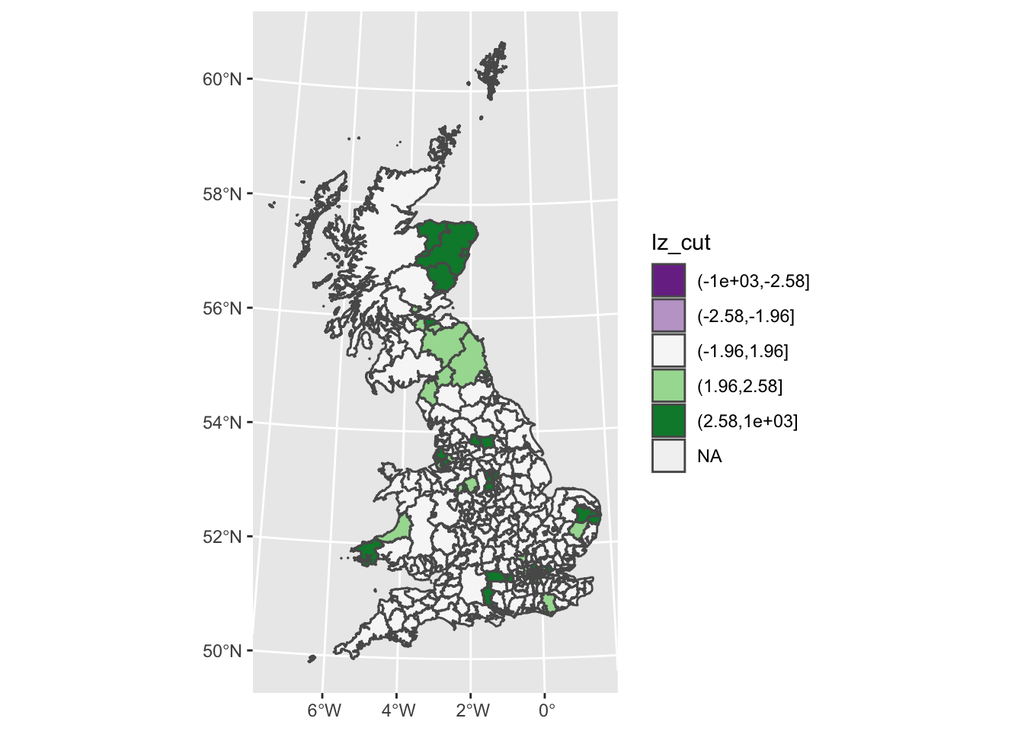

```r
local <- localmoran(UA_df$z,lw,zero.policy = TRUE) %>% as.data.frame()
UA_df <- bind_cols(UA_df,local)
breaks<-c(-1000,-2.58,-1.96,1.96,2.58,1000)
UA_df$Iz_cut <- cut(UA_df$Z.Ii,breaks)
ggplot(UA_df)+geom_sf(aes(fill=Iz_cut))+scale_fill_brewer(palette = "PRGn",drop=FALSE)+ theme(legend.position = "right")+guides(fill = "legend")
```

# Appendix: Model building process

## Preprocessing

The first step in the process is to reduce the independent variables from 432 to 39 which may potentially be relevant.

```r
require(tidyverse)
require(sf)
require(httr)
require(jsonlite)
require(spaMM)
require(spdep)
require(spatstat)
require(ResourceSelection)
require(mfp)
require(ggplot2)
hh = read_tsv(paste('../UKDA-7553-tab/tab/','household_special_2002-2019_protect.tab',sep='/'))

#identified social-economic characteristics
features <- c('AddressType_B01ID',            # Type of property found at the address
              'BlueBdg_B01ID',                # Does anyone in household have a blue badge
              'CarPool_B01ID',                # Use of car from company car-pool
              'ConcTravElig_B01ID',           # Concessionary Travel Survey - Eligibility for elderly person concessionary travel scheme
              'ConcTravFare_B01ID',           # Concessionary Travel Survey - Type of bus fare concession
              'HHoldAreaType1_B01ID',         # Household Area Type - Settlement size (urban/rural) excluding South Yorkshire in Metropolitan Areas - 15 categories
              'HHoldAreaType2_B01ID',         # Household Area Type - Settlement size (urban/rural) including South Yorkshire in Metropolitan Areas - 16 categories
              'HHoldAreaType2_B02ID',         # Household Area Type - Settlement size (urban/rural) including South Yorkshire in Metropolitan Areas - 7 categories
              'HHoldCVAvail_B01ID',           # Car / light van (including landrover, jeep, minibus etc) availability in household
              'HHoldEmploy_B01ID',            # Number of employed in household - broken down by full and part time workers
              'HHoldFulltime',                # Number of full time workers in household
              'HHIncome2002_B01ID',            # Household income
              'HHoldNumAdults',               # Number of adults in household - actual number
              'HHoldNumChildren',             # Number of children in household - actual number
              'HHoldNumPeople',               # Total number of people in household - actual number
              'HHoldOAClass2011_B01ID',       # 2011 Census Output Area Classification - Subgroup - 76 bands
              'HHoldOAClass2011_B02ID',       # 2011 Census Output Area Classification - Group - 26 bands
              'HHoldOAClass2011_B03ID',       # 2011 Census Output Area Classification - SuperGroup - 8 bands
              'HHoldOSWard_B01ID',            # ONS ward code
              'HHoldPartTime',                # Number of part time workers in household
              'HHoldStruct_B01ID',            # Household structure - 33 categories
              'HHoldStruct_B03ID',            # Household structure - 10 categories
              'HRPAgeSex_B01ID',              # Household Reference Person (HRP) - Age and Gender
              'HRPEmpStat_B01ID',             # Household Reference Person (HRP) - employment status
              'HRPSEG_B01ID',                 # Household Reference Person (HRP) - Socio Economic Group (SEG)
              'HRPSIC2007_B02ID',             # Household Reference Person (HRP) - Standard Industrial Classification (SIC) - 2007 bandings  - Summary - 21 categories
              'HRPWorkStat_B01ID',            # Household Reference Person (HRP) - working status - 7 categories
              'IMD2010Rank_B01ID',            # Index of multiple deprivation - banded value - 2010 bandings - England only
              'NumVehicles',                  # Number of household vehicles - actual number
              'ONSACGrp_B01ID',               #  Household NS 2001 Area Classification of wards Group Level
              'ONSACSub_B01ID',               # Household NS 2001 Area Classification of wards Sub-Group Level
              'ONSACSup_B01ID',               # Household NS 2001 Area Classification of wards Super Group Level
              'Settlement2011EW_B01ID',       # ONS Rural-Urban Classification of residence- 2011 Census - 18 categories
              'Settlement2011EW_B02ID',       # ONS Rural-Urban Classification of residence- 2011 Census - 5 categories
              'SettlementEW_B01ID',           # Household ONS/DEFRA urban and rural classification - England and Wales
              'Ten1_B01ID')                   # Type of tenancy - 6 categories

#provide imputation indicator
data.reduced  <- hh %>% filter(HHIncOrig_B01ID!=4) %>% mutate(imputed=HHIncOrig_B01ID==3) %>% dplyr::select(imputed,PSUID,SurveyYear,features,UA=HHoldOSLAUA_B01ID,ward=HHoldOSWard_B01ID)

#Add LA geography
UA_geo <- st_read('../wardlookup/LA_geometry_2016/Local_Authority_Districts__December_2016__GB_BGC.shp') %>% st_transform(27700) %>% dplyr::select(LAD16CD,LAD16NM)
coords <- UA_geo %>% st_centroid() %>% st_coordinates()
UA_geo$coord.x <- coords[,'X']
UA_geo$coord.y <- coords[,'Y']

#LAD census codes have been recoded since the historic surveys and need updating to present current day
missing_codes <- data.reduced[['UA']][!(data.reduced[['UA']] %in% UA_geo[['LAD16CD']])] %>% unique()


website=("https://findthatpostcode.uk/areas/")
replacement <- map_chr(missing_codes,
                       ~GET(paste0(website,.x,".json"))
                       %>% content(as='text')
                       %>% fromJSON()
                       %>% {.$data$relationships$successor$data$id[1]}
)
names(replacement) <- missing_codes
data.reduced[,'UA'] <- dplyr::recode(data.reduced[['UA']],!!!replacement)
# data.reduced <- UA_geo %>% left_join(data,by=c('LAD16CD'='UA')) %>% rename(UA=LAD16CD)
```

The data is then preprocessed to:

- include observation survey year, in case of varying missingness over time. This is obtained by joining the Household data to Primary Sample Unit data in the NTS dataset via a sampling unit ID.
- recode the factors to a meaningful text value using a NTS data dictionary. Age and gender are subsequently deduced from coding, and age and gender and income converted to ordinal data from their banded values.

```r
psu= read_tsv(paste('../UKDA-7553-tab/tab/','psu_special_2002-2019_protect.tab',sep='/'))
data.reduced <-  data.reduced%>% left_join(psu %>% dplyr::select(PSUID,SurveyYear)) %>% dplyr::select(!PSUID)
data.recoded <- data.reduced%>%
  mutate(
    gender=case_when(HRPAgeSex_B01ID==-8 ~ NA_character_,
                     HRPAgeSex_B01ID<10  ~ "M",
                     TRUE ~ "F"),
    age_band= case_when(HRPAgeSex_B01ID==-8 ~ NA_real_,
                        gender=="M"  ~ HRPAgeSex_B01ID,
                        TRUE ~ HRPAgeSex_B01ID-9),
    IMD2010=IMD2010Rank_B01ID %>% na_if(-8) %>% na_if(-9)
  ) %>%
  dplyr::select(!c(HRPAgeSex_B01ID,IMD2010Rank_B01ID)) %>%
  mutate(across(matches("B0[1-3]ID$"),factor))


#read in our dictionary of banded variables

factor_dic <- readxl::read_excel('../UKDA-7553-tab/mrdoc/excel/7553_nts_lookup_table_banded_variables_2018.xlsx',sheet = 'Household LUT',col_types = 'text') %>%
  dplyr::select(var=`SQL variable name`,factor_=`New Value`,level_=`Values Description`)
factor_dic <- fill(factor_dic,var)
factor_list <- factor_dic %>% nest_by(var) %>% ungroup()
factor_list$coding=factor_list$data %>% map(~set_names(.x$factor_,.x$level_))

data.reduced %>% dplyr::select(where(is.factor)) %>% colnames() %>%
  map_lgl(~any(grepl(.x,factor_list$var,ignore.case=TRUE))) %>%  all() %>%
  print() # case-insensitive search

recode <- function(data,id){
  names <-  factor_list[grepl(id,factor_list$var,ignore.case=TRUE),] %>%{.$coding[[1]]}
  return(fct_recode(data,!!!names))
}

data.recoded <- data.recoded %>% mutate(across(where(is.factor),~recode(.x,cur_column())))
data.recoded <- data.recoded %>% mutate(across(where(is.factor),~factor(replace(.x, .x == "NA", NA))))
data.recoded$gender <- factor(data.recoded$gender)
data.recoded$HHincome <- data.recoded$HHIncome2002_B01ID %>% gsub(",","",.) %>% regmatches(.,gregexpr('\\d*,?\\d+',.)) %>% map_dbl(~mean(as.numeric(.x)))/1000
data.recoded <- data.recoded %>% dplyr::select(-HHIncome2002_B01ID)
```

Areal level income estimates are included using the following approach. In order to associate household location from the survey, which is available at a ward level, with income estimates, generated at an MSOA level,a lookup table of income is created for each ward. The geometries for the wards and the MSOA are loaded and a spatial join performed based on nearest matching feature using the polygon centroids. As part of this, historic ward information is matched to current day wards.

c.50,000 observations are lost during the the matching process, because disclosure of ward information stopped in 2016 with only UA location given thereafter. Ward location is preferred to give closer matching to the MSOA-income.

```r
# create a lookup table from historic ward (inNTS survey) to 2016 ward and MSOA
ward2016 <- st_read('../wardlookup/geometry_2016/Wards__December_2016__Boundaries_UK_BGC.shp') %>% st_transform(27700) %>% st_centroid() %>% dplyr::select(code="WD16CD")
ward2015 <- st_read('../wardlookup/geometry_2015/Wards_(December_2015)_Boundaries.shp')  %>% st_transform(27700) %>% st_centroid() %>% dplyr::select(code="wd15cd")
ward2011 <- st_read('../wardlookup/geometry_2011/Wards_(December_2011)_Boundaries_EW_BGC.shp') %>% st_transform(27700) %>% st_centroid() %>% dplyr::select(code="wd11cd")

lookup <- bind_rows(ward2016,ward2015,ward2011) %>%
  {.[!duplicated(.$code),]} %>%
  st_join(ward2016,st_nearest_feature) %>%
  dplyr::select(code=code.x,code2016=code.y)

msoa2011 <- st_read('../wardlookup/msoa_geometry_2011/Middle_Layer_Super_Output_Areas_(December_2011)_Boundaries_Generalised_Clipped_(BGC)_EW_V3.shp')%>% st_transform(27700) %>% st_centroid() %>% dplyr::select(msoa="MSOA11CD")

lookup <- lookup %>% st_join(msoa2011,st_nearest_feature)

# Income estimate by ward
filepath = '../ons_est_income/'
filename='total.csv'
colnames = read_lines(paste(filepath,filename,sep='/'),skip=4,n_max=1) %>% str_split(',') %>% .[[1]]
colnames2 = map_chr(colnames,~strsplit(.x,' \\(') %>% {.[[1]][[1]]})
lookup <- left_join(lookup,read_csv(paste(filepath,filename,sep='/'),skip=5,col_names=colnames2) %>%
  dplyr::select(msoa=`MSOA code`,income=`Total annual income`))
data.recoded <-  lookup %>% dplyr::select(income,code2016) %>% inner_join(data.recoded,by=c('code2016'='ward')) %>%  mutate(income=income/1000)

ggplot(data.recoded)+geom_point(aes(x=income,y=HHincome),alpha=0.2,size=1)+geom_smooth(aes(x=income,y=HHincome))+scale_x_log10()+scale_y_log10()+labs(title='Survey household income against areal estimates',x='Areal Income',y='Household Income')
```

## Univariate analysis

Having preprocessed the data, variable selection proceeds by undertaking univariate analysis by contingency table chi-square testing on factors. We subset the data to 5,000 observations to reduce the sensitivity to small effects.

```r
factors <- data.recoded %>% st_drop_geometry() %>% dplyr::select(where(is.factor))  %>% colnames()
data.sample <- data.recoded %>% slice_sample(n=5000)
tables=factors %>% map(~table(data.sample$imputed,data.sample[[.x]],
                    exclude=c('-10',NA,'DNA')) %>% {.[,marginSums(.,2)>0]})

p.value <- tables %>%  map_dbl(~ chisq.test(.x) %>% {.$p.value})
odds.ratio <- tables %>% map_dbl(~prop.table(.x,2) %>% {.[1,]/.[2,]} %>% {(max(.,na.rm=TRUE)/min(.,na.rm=TRUE))})
univariate.factors <- tibble(factors,p.value,odds.ratio) %>% {.[order(p.value>0.05,-odds.ratio),]}
univariate.factors
```

```
## # A tibble: 27 x 3
##    factors                 p.value odds.ratio
##    <chr>                     <dbl>      <dbl>
##  1 HHoldOAClass2011_B01ID 3.72e- 2     Inf
##  2 HHoldOAClass2011_B02ID 4.14e- 2     Inf
##  3 HHoldStruct_B01ID      1.11e-13     Inf
##  4 Settlement2011EW_B01ID 3.56e- 2     Inf
##  5 HRPSEG_B01ID           4.00e- 6       8.08
##  6 Ten1_B01ID             4.79e-10       4.86
##  7 AddressType_B01ID      4.44e- 3       3.63
##  8 HHoldStruct_B03ID      1.88e-19       3.08
##  9 HRPWorkStat_B01ID      2.54e- 8       2.99
## 10 ONSACGrp_B01ID         4.14e- 2       2.42
## # … with 17 more rows
```

Investigating key factors further, it appears household structure as a combination of age and number of adults has a sizable effect. Otherwise there are a employment related indicators that have an effect, as does geography in a number of different areal classifications: London has a very significant geographic effect.

```r
data.recoded %>% st_drop_geometry() %>% dplyr::select(imputed,HHoldStruct_B03ID) %>% table(exclude=c('-10',NA)) %>% prop.table(margin=2)
```

```
##        HHoldStruct_B03ID
## imputed Single adult 65 years + Single adult 16-64 years
##   FALSE               0.7717470                0.8739408
##   TRUE                0.2282530                0.1260592
##        HHoldStruct_B03ID
## imputed Two adults, Hoh / HRP 65 years + Two adults, Hoh / HRP 16-64 years
##   FALSE                        0.7153788                         0.7918019
##   TRUE                         0.2846212                         0.2081981
##        HHoldStruct_B03ID
## imputed 3 adults or more Single parent family 2 adults, 1 child
##   FALSE        0.7019076            0.8313157         0.8388626
##   TRUE         0.2980924            0.1686843         0.1611374
##        HHoldStruct_B03ID
## imputed 2 adults, 2 children 2 adults, 3 children or more
##   FALSE            0.8346683                    0.8272727
##   TRUE             0.1653317                    0.1727273
##        HHoldStruct_B03ID
## imputed 3 adults or more, 1 child or more
##   FALSE                         0.7451576
##   TRUE                          0.2548424
```

```r
data.recoded  %>% st_drop_geometry() %>% dplyr::select(imputed,HHoldAreaType2_B02ID) %>% table(exclude=c('-10',NA)) %>% prop.table(margin=2)
```

```
##        HHoldAreaType2_B02ID
## imputed London Boroughs Metropolitan built-up areas
##   FALSE       0.7158341                   0.7941683
##   TRUE        0.2841659                   0.2058317
##        HHoldAreaType2_B02ID
## imputed Large urban (over 250k population)
##   FALSE                          0.7962949
##   TRUE                           0.2037051
##        HHoldAreaType2_B02ID
## imputed Medium urban (25k to 250k population)
##   FALSE                             0.8101696
##   TRUE                              0.1898304
##        HHoldAreaType2_B02ID
## imputed Small / medium urban (10k to 25k population)
##   FALSE                                    0.8068466
##   TRUE                                     0.1931534
##        HHoldAreaType2_B02ID
## imputed Small urban (3k to 10k population)     Rural
##   FALSE                          0.8051929 0.7925920
##   TRUE                           0.1948071 0.2074080
```

```r
data.recoded  %>% st_drop_geometry() %>% dplyr::select(imputed,HRPEmpStat_B01ID) %>% table(exclude=c('-10',NA)) %>% prop.table(margin=2)
```

```
##        HRPEmpStat_B01ID
## imputed Self employed Employed manager Other employee Never worked
##   FALSE     0.7295365        0.8223273      0.7979183    0.6370410
##   TRUE      0.2704635        0.1776727      0.2020817    0.3629590
```

```r
nonfactors <- data.recoded %>% st_drop_geometry() %>% dplyr::select(!where(is.factor)) %>% dplyr::select(-c(imputed,code2016))%>% colnames()
univariate.regression <-  nonfactors  %>% map(~paste0('imputed~',.x) %>% as.formula())  %>% map_dfr(~glm(.x,data=data.sample,family='binomial') %>% broom::tidy() %>% {.[2,c('term','estimate','statistic')]})
univariate.regression[order(abs(univariate.regression$statistic),decreasing = TRUE),]
```

```
## # A tibble: 12 x 3
##    term              estimate statistic
##    <chr>                <dbl>     <dbl>
##  1 age_band          0.133        8.15
##  2 HHoldNumAdults    0.222        5.70
##  3 income            0.0105       3.04
##  4 SurveyYear        0.0206       2.56
##  5 HHoldNumPeople    0.0623       2.40
##  6 HHoldNumChildren -0.0725      -1.84
##  7 IMD2010           0.0222       1.68
##  8 UAE06000003       1.20         1.01
##  9 HHoldFulltime    -0.0206      -0.472
## 10 HHoldPartTime    -0.0230      -0.348
## 11 HHincome         -0.000344    -0.247
## 12 NumVehicles       0.00645      0.175
```

## Reducing the model

```r
data <- data.recoded %>% dplyr::select(!starts_with('ONSAC')) %>% dplyr::select(-c(BlueBdg_B01ID,ConcTravFare_B01ID,IMD2010,SettlementEW_B01ID,HRPSIC2007_B02ID)) %>% mutate(across(where(is.factor),~factor(replace(.x, .x == "-10", NA)))) %>% na.omit()
```

To undertake a multivariate analysis it is firstly necessary to clean the data set to remove partial cases - these typically relate to the change over time of recorded information (coded as -10 in the data when a question was not asked). As part of this we remove insignificant features with a high number of missing results. NB: ONSAC…. groupings are a geodemographic variable superceded by HHoldOAClass2011… since 2014. We use the latter only. This reduces the data set size to 18011 observations.

An initial model is produced using all significant factors identified in the univariate analysis above, (plus gender even though it was not a significant univariate), using the coarsest possible bandings where there is a choice of granularity. 15 factors in total. A number of variables were removed on the basis that they heavily overlap with other variables, picking the coarsest possible grouping available. For example, household income was excluded to prefer UA income, and factors relating to household structure were excluded in preference to age, number of adults and number of children.

```r
initial.factors <- c(c('HHoldNumAdults','age_band','HHoldNumChildren','income','SurveyYear'),
                    c("HRPSEG_B01ID","HRPEmpStat_B01ID","Ten1_B01ID","HHoldOAClass2011_B03ID","HRPWorkStat_B01ID","Settlement2011EW_B01ID","CarPool_B01ID","HHoldAreaType2_B02ID","AddressType_B01ID","gender"))
f <- as.formula(paste0('imputed ~',paste(initial.factors,collapse= " + ")))
full.model <- glm(f, data = data, family = binomial)
print(broom::tidy(full.model))
```

```
## # A tibble: 68 x 5
##    term                         estimate std.error statistic  p.value
##    <chr>                           <dbl>     <dbl>     <dbl>    <dbl>
##  1 (Intercept)                 -70.4      45.7         -1.54 1.23e- 1
##  2 HHoldNumAdults                0.307     0.0233      13.2  1.05e-39
##  3 age_band                      0.142     0.0158       9.00 2.18e-19
##  4 HHoldNumChildren              0.0458    0.0240       1.91 5.62e- 2
##  5 income                        0.00322   0.00246      1.31 1.90e- 1
##  6 SurveyYear                    0.0342    0.0227       1.51 1.31e- 1
##  7 HRPSEG_B01IDEmployer: large  -0.688     0.425       -1.62 1.05e- 1
##  8 HRPSEG_B01IDManager: large   -0.878     0.174       -5.05 4.39e- 7
##  9 HRPSEG_B01IDEmployer: small  -0.281     0.150       -1.87 6.10e- 2
## 10 HRPSEG_B01IDManager: small   -0.831     0.191       -4.36 1.33e- 5
## # … with 58 more rows
```

We subject this initial model to variable removal and likelihood ratio testing to identify non-significant variables. Income appears insignificant but kept in. HRPSEG_B01ID was removed despite being significant as there is a large overlap with HRPEmpStat_B01ID as a coarser feature. CarPool was removed as the significance arose from the number of “DNA” answers which is a poor causal factor for income imputation, as opposed to an overlapping outcome.

```r
drop1(full.model,test="LRT")
```

```
## Single term deletions
##
## Model:
## imputed ~ HHoldNumAdults + age_band + HHoldNumChildren + income +
##     SurveyYear + HRPSEG_B01ID + HRPEmpStat_B01ID + Ten1_B01ID +
##     HHoldOAClass2011_B03ID + HRPWorkStat_B01ID + Settlement2011EW_B01ID +
##     CarPool_B01ID + HHoldAreaType2_B02ID + AddressType_B01ID +
##     gender
##                        Df Deviance   AIC     LRT  Pr(>Chi)
## <none>                       18452 18586
## HHoldNumAdults          1    18626 18758 173.213 < 2.2e-16 ***
## age_band                1    18534 18666  82.086 < 2.2e-16 ***
## HHoldNumChildren        1    18456 18588   3.613 0.0573262 .
## income                  1    18454 18586   1.712 0.1907015
## SurveyYear              1    18455 18587   2.276 0.1314318
## HRPSEG_B01ID           18    18528 18626  75.304 5.608e-09 ***
## HRPEmpStat_B01ID        2    18453 18583   0.318 0.8530434
## Ten1_B01ID              4    18463 18589  10.985 0.0267326 *
## HHoldOAClass2011_B03ID  7    18465 18585  12.532 0.0843602 .
## HRPWorkStat_B01ID       6    18479 18601  26.992 0.0001453 ***
## Settlement2011EW_B01ID  9    18468 18584  15.852 0.0700377 .
## CarPool_B01ID           2    18468 18598  15.748 0.0003804 ***
## HHoldAreaType2_B02ID    6    18534 18656  81.738 1.562e-15 ***
## AddressType_B01ID       5    18481 18605  28.977 2.343e-05 ***
## gender                  1    18459 18591   6.341 0.0117962 *
## ---
## Signif. codes:  0 '***' 0.001 '**' 0.01 '*' 0.05 '.' 0.1 ' ' 1
```

```r
main.model <- update(full.model,. ~. - CarPool_B01ID - Settlement2011EW_B01ID - HRPSEG_B01ID -HHoldOAClass2011_B03ID - SurveyYear)
drop1(full.model,test="LRT")
```

```
## Single term deletions
##
## Model:
## imputed ~ HHoldNumAdults + age_band + HHoldNumChildren + income +
##     SurveyYear + HRPSEG_B01ID + HRPEmpStat_B01ID + Ten1_B01ID +
##     HHoldOAClass2011_B03ID + HRPWorkStat_B01ID + Settlement2011EW_B01ID +
##     CarPool_B01ID + HHoldAreaType2_B02ID + AddressType_B01ID +
##     gender
##                        Df Deviance   AIC     LRT  Pr(>Chi)
## <none>                       18452 18586
## HHoldNumAdults          1    18626 18758 173.213 < 2.2e-16 ***
## age_band                1    18534 18666  82.086 < 2.2e-16 ***
## HHoldNumChildren        1    18456 18588   3.613 0.0573262 .
## income                  1    18454 18586   1.712 0.1907015
## SurveyYear              1    18455 18587   2.276 0.1314318
## HRPSEG_B01ID           18    18528 18626  75.304 5.608e-09 ***
## HRPEmpStat_B01ID        2    18453 18583   0.318 0.8530434
## Ten1_B01ID              4    18463 18589  10.985 0.0267326 *
## HHoldOAClass2011_B03ID  7    18465 18585  12.532 0.0843602 .
## HRPWorkStat_B01ID       6    18479 18601  26.992 0.0001453 ***
## Settlement2011EW_B01ID  9    18468 18584  15.852 0.0700377 .
## CarPool_B01ID           2    18468 18598  15.748 0.0003804 ***
## HHoldAreaType2_B02ID    6    18534 18656  81.738 1.562e-15 ***
## AddressType_B01ID       5    18481 18605  28.977 2.343e-05 ***
## gender                  1    18459 18591   6.341 0.0117962 *
## ---
## Signif. codes:  0 '***' 0.001 '**' 0.01 '*' 0.05 '.' 0.1 ' ' 1
```

```r
print(broom::tidy(main.model))
```

```
## # A tibble: 30 x 5
##    term                                                     estimate std.error statistic  p.value
##    <chr>                                                       <dbl>     <dbl>     <dbl>    <dbl>
##  1 (Intercept)                                             -1.60       0.186      -8.59  8.52e-18
##  2 HHoldNumAdults                                           0.340      0.0222     15.3   1.17e-52
##  3 age_band                                                 0.138      0.0155      8.90  5.55e-19
##  4 HHoldNumChildren                                         0.0471     0.0239      1.97  4.86e- 2
##  5 income                                                   0.000906   0.00230     0.394 6.94e- 1
##  6 HRPEmpStat_B01IDEmployed manager                        -0.374      0.0778     -4.81  1.55e- 6
##  7 HRPEmpStat_B01IDOther employee                          -0.274      0.0527     -5.20  2.02e- 7
##  8 HRPEmpStat_B01IDNever worked                             0.520      0.108       4.82  1.41e- 6
##  9 Ten1_B01IDBuying it with the help of a mortgage or loan -0.180      0.0557     -3.23  1.24e- 3
## 10 Ten1_B01IDPart own and part rent                        -0.291      0.256      -1.14  2.55e- 1
## # … with 20 more rows
```

While the remaining factor variables in the model are significant, many of the factor levels have similar effects and hence factors are recoded to merge similar effects. Number of children is split into an indicator for having children and a separate variable for the number of children. Upon refitting the model, children is no longer a significant indicator, and Tenancy type and Address Type are removed because of their unclear causal links with response and the potential for interactions with other features.A log transform is taken for income given typical income distribution skew. A reduced model is considered which removes HHoldAreaType2_B02ID as geographic indicator, to compare the effect on the income coefficient.

```r
data.recoded2 <- data.recoded
data.recoded2$children <- (data.recoded2$HHoldNumChildren>0)
levels(data.recoded2$HRPWorkStat_B01ID) <- c("Working","Working","Other non-working","Retired/Permanently Sick","Other non-working","Other non-working","Other non-working")
levels(data.recoded2$AddressType_B01ID) <- c("House / bungalow (detached)","House / bungalow (semi-detached)","House / bungalow (terrace / end terrace)", "Other",
                                            "Flat","Flat","Flat","Other")
data <- data.recoded2 %>% st_drop_geometry() %>% dplyr::select(!starts_with('ONSAC')) %>% dplyr::select(-c(BlueBdg_B01ID,ConcTravFare_B01ID,IMD2010,SettlementEW_B01ID,HRPSIC2007_B02ID)) %>% mutate(across(where(is.factor),~factor(replace(.x, .x == "-10", NA)))) %>% na.omit()
main.model <- glm(main.model$formula,data=data,family=binomial)
main.model <- update(main.model,.~. + children)
print(broom::tidy(full.model))
```

```
## # A tibble: 68 x 5
##    term                         estimate std.error statistic  p.value
##    <chr>                           <dbl>     <dbl>     <dbl>    <dbl>
##  1 (Intercept)                 -70.4      45.7         -1.54 1.23e- 1
##  2 HHoldNumAdults                0.307     0.0233      13.2  1.05e-39
##  3 age_band                      0.142     0.0158       9.00 2.18e-19
##  4 HHoldNumChildren              0.0458    0.0240       1.91 5.62e- 2
##  5 income                        0.00322   0.00246      1.31 1.90e- 1
##  6 SurveyYear                    0.0342    0.0227       1.51 1.31e- 1
##  7 HRPSEG_B01IDEmployer: large  -0.688     0.425       -1.62 1.05e- 1
##  8 HRPSEG_B01IDManager: large   -0.878     0.174       -5.05 4.39e- 7
##  9 HRPSEG_B01IDEmployer: small  -0.281     0.150       -1.87 6.10e- 2
## 10 HRPSEG_B01IDManager: small   -0.831     0.191       -4.36 1.33e- 5
## # … with 58 more rows
```

```r
drop1(main.model,test="LRT")
```

```
## Single term deletions
##
## Model:
## imputed ~ HHoldNumAdults + age_band + HHoldNumChildren + income +
##     HRPEmpStat_B01ID + Ten1_B01ID + HRPWorkStat_B01ID + HHoldAreaType2_B02ID +
##     AddressType_B01ID + gender + children
##                      Df Deviance   AIC     LRT  Pr(>Chi)
## <none>                     18584 18636
## HHoldNumAdults        1    18818 18868 233.481 < 2.2e-16 ***
## age_band              1    18659 18709  75.027 < 2.2e-16 ***
## HHoldNumChildren      1    18588 18638   3.473 0.0623641 .
## income                1    18584 18634   0.211 0.6458914
## HRPEmpStat_B01ID      3    18682 18728  97.890 < 2.2e-16 ***
## Ten1_B01ID            4    18594 18638   9.710 0.0456132 *
## HRPWorkStat_B01ID     2    18591 18639   6.352 0.0417460 *
## HHoldAreaType2_B02ID  6    18848 18888 263.987 < 2.2e-16 ***
## AddressType_B01ID     4    18604 18648  20.086 0.0004803 ***
## gender                1    18592 18642   7.779 0.0052868 **
## children              1    18586 18636   1.330 0.2487453
## ---
## Signif. codes:  0 '***' 0.001 '**' 0.01 '*' 0.05 '.' 0.1 ' ' 1
```

```r
full.model <- update(full.model,.~. - income + log(income) - children -HHoldNumChildren - Ten1_B01ID - AddressType_B01ID)
print(broom::tidy(full.model))
```

```
## # A tibble: 54 x 5
##    term                                    estimate std.error statistic  p.value
##    <chr>                                      <dbl>     <dbl>     <dbl>    <dbl>
##  1 (Intercept)                             -73.4      45.6        -1.61 1.07e- 1
##  2 HHoldNumAdults                            0.307     0.0227     13.5  1.27e-41
##  3 age_band                                  0.149     0.0140     10.6  1.79e-26
##  4 SurveyYear                                0.0354    0.0226      1.57 1.17e- 1
##  5 HRPSEG_B01IDEmployer: large              -0.614     0.423      -1.45 1.46e- 1
##  6 HRPSEG_B01IDManager: large               -0.836     0.172      -4.86 1.15e- 6
##  7 HRPSEG_B01IDEmployer: small              -0.261     0.148      -1.76 7.81e- 2
##  8 HRPSEG_B01IDManager: small               -0.799     0.189      -4.22 2.40e- 5
##  9 HRPSEG_B01IDProfessional: self employed  -0.992     0.188      -5.29 1.22e- 7
## 10 HRPSEG_B01IDProfessional: employee       -1.01      0.172      -5.90 3.72e- 9
## # … with 44 more rows
```

```r
reduced.model <- update(full.model,.~ .-HHoldAreaType2_B02ID)
print(broom::tidy(reduced.model))
```

```
## # A tibble: 48 x 5
##    term                                    estimate std.error statistic  p.value
##    <chr>                                      <dbl>     <dbl>     <dbl>    <dbl>
##  1 (Intercept)                             -70.5      45.4        -1.55 1.20e- 1
##  2 HHoldNumAdults                            0.312     0.0226     13.8  2.29e-43
##  3 age_band                                  0.152     0.0140     10.8  2.00e-27
##  4 SurveyYear                                0.0332    0.0225      1.47 1.40e- 1
##  5 HRPSEG_B01IDEmployer: large              -0.638     0.421      -1.52 1.29e- 1
##  6 HRPSEG_B01IDManager: large               -0.852     0.171      -4.98 6.52e- 7
##  7 HRPSEG_B01IDEmployer: small              -0.281     0.147      -1.90 5.70e- 2
##  8 HRPSEG_B01IDManager: small               -0.820     0.188      -4.35 1.35e- 5
##  9 HRPSEG_B01IDProfessional: self employed  -1.02      0.187      -5.44 5.30e- 8
## 10 HRPSEG_B01IDProfessional: employee       -1.03      0.171      -6.02 1.70e- 9
## # … with 38 more rows
```

It is clear that London boroughs (and other urban areas to a lesser extent) have markedly higher levels of missing income responses, that affect any regression of income using ward level aggregates. The income coefficient for the model including HHoldAreaType2_B02ID is 0.1041874 and excluding it is 0.4270721

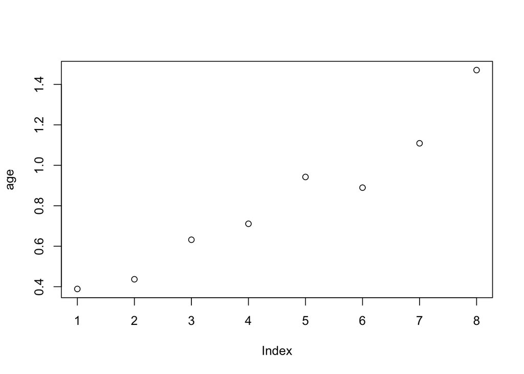

```r
age.model <- update(full.model,.~ . - age_band+factor(age_band))
age <- coef(age.model) %>% {.[grepl("^factor", names(.))]}
plot(age)
```

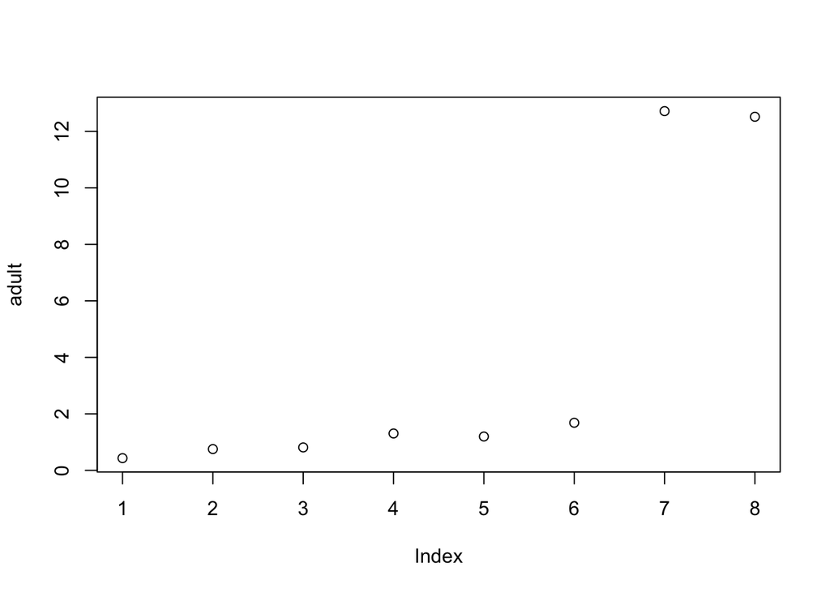

```r
adult.model <- update(full.model,.~ . -HHoldNumAdults +factor(HHoldNumAdults))
adult <- coef(adult.model) %>% {.[grepl("^factor", names(.))]}
plot(adult)
```

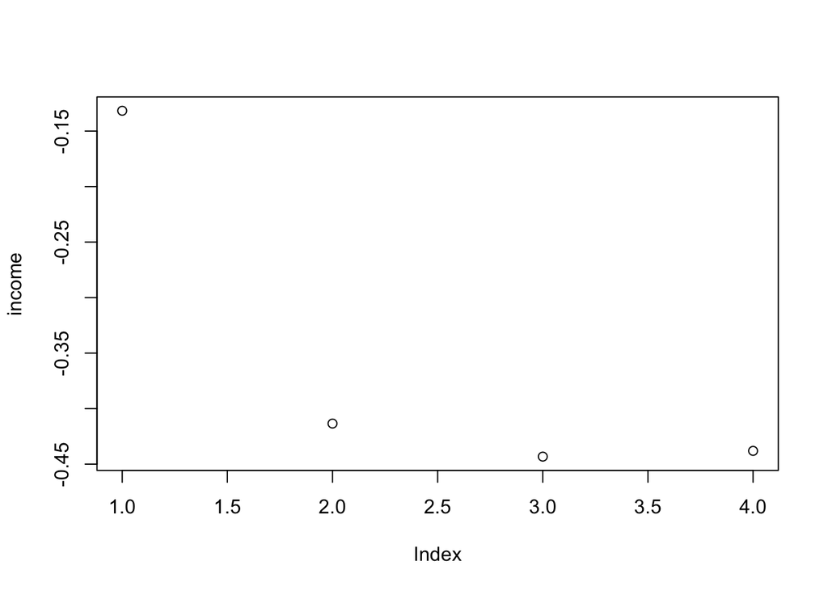

```r
income.model <- update(full.model,.~ . -income +cut(income,include.lowest=T,breaks=(quantile(income,probs = seq(0, 1, by = 0.20)))))
income <- coef(income.model) %>% {.[grepl("^cut", names(.))]}
plot(income)
```

```r
f <- mfp(imputed ~  fp(HHoldNumAdults) + fp( age_band ) + fp(log(income)) + HRPEmpStat_B01ID +
    HRPWorkStat_B01ID  + HHoldAreaType2_B02ID +
    gender, data = data, family = binomial)

summary(f)
```

```
##
## Call:
## glm(formula = imputed ~ I(HHoldNumAdults^0.5) + HHoldAreaType2_B02ID +
##     I((age_band/10)^1) + HRPEmpStat_B01ID + HRPWorkStat_B01ID +
##     gender + I((log(income)/10)^3) + I((log(income)/10)^3 * log((log(income)/10))),
##     family = binomial, data = data)
##
## Deviance Residuals:
##     Min       1Q   Median       3Q      Max
## -2.0596  -0.7513  -0.6108  -0.4356   2.2730
##
## Coefficients:
##                                                                   Estimate
## (Intercept)                                                       -0.03358
## I(HHoldNumAdults^0.5)                                              1.04213
## HHoldAreaType2_B02IDMetropolitan built-up areas                   -0.43727
## HHoldAreaType2_B02IDLarge urban (over 250k population)            -0.63599
## HHoldAreaType2_B02IDMedium urban (25k to 250k population)         -0.75277
## HHoldAreaType2_B02IDSmall / medium urban (10k to 25k population)  -0.68152
## HHoldAreaType2_B02IDSmall urban (3k to 10k population)            -1.05862
## HHoldAreaType2_B02IDRural                                         -0.82826
## I((age_band/10)^1)                                                 1.47831
## HRPEmpStat_B01IDEmployed manager                                  -0.36961
## HRPEmpStat_B01IDOther employee                                    -0.29224
## HRPEmpStat_B01IDNever worked                                       0.51484
## HRPWorkStat_B01IDOther non-working                                 0.17669
## HRPWorkStat_B01IDRetired/Permanently Sick                          0.17073
## genderM                                                           -0.11268
## I((log(income)/10)^3)                                             98.28650
## I((log(income)/10)^3 * log((log(income)/10)))                    151.27318
##                                                                  Std. Error
## (Intercept)                                                         0.97129
## I(HHoldNumAdults^0.5)                                               0.06466
## HHoldAreaType2_B02IDMetropolitan built-up areas                     0.06704
## HHoldAreaType2_B02IDLarge urban (over 250k population)              0.06816
## HHoldAreaType2_B02IDMedium urban (25k to 250k population)           0.06217
## HHoldAreaType2_B02IDSmall / medium urban (10k to 25k population)    0.08554
## HHoldAreaType2_B02IDSmall urban (3k to 10k population)              0.08693
## HHoldAreaType2_B02IDRural                                           0.06991
## I((age_band/10)^1)                                                  0.13680
```

[output cut: 39 more lines]

```
## HRPWorkStat_B01IDOther non-working                                0.03154 *
## HRPWorkStat_B01IDRetired/Permanently Sick                         0.00489 **
## genderM                                                           0.00417 **
## I((log(income)/10)^3)                                             0.00435 **
## I((log(income)/10)^3 * log((log(income)/10)))                     0.00499 **
## ---
## Signif. codes:  0 '***' 0.001 '**' 0.01 '*' 0.05 '.' 0.1 ' ' 1
##
## (Dispersion parameter for binomial family taken to be 1)
##
##     Null deviance: 19604  on 18010  degrees of freedom
## Residual deviance: 18603  on 17994  degrees of freedom
## AIC: 18637
##
## Number of Fisher Scoring iterations: 4
```

Having reduced the variables down to a main effects model, the process is not continued to test excluded variables for remaining significance or consider interactions. The purpose of the model is to distinguish confounding factors for an income regression, and by comparing the coefficients for the main effects model to a univariate and ‘full’ model (one with all the initially considered variables) it can be seen that the main model and full model have similar effects.

The models are refit on the full data set. The coefficients show that the largest effects are due to the number of adults in the household (understandable as it is an estimate of combined household income) and age. The employment status and type of employment of the household reference person also has an effect, with large positive effects if the HRP is self-employed or has never worked. Gender has a minor effect. Income also has a minor effect, and it is not-statistically significant, which must be considered in the context of the c.100,000 observations being used. HHIncome as an alternaitve income estiamte is statistically significant and reveals a similar effect size.

```r
data <- data.recoded2 %>% filter(!is.na(HHoldNumAdults),!is.na(age_band),!is.na(HRPEmpStat_B01ID),!is.na(HRPWorkStat_B01ID),!is.na(HHoldAreaType2_B02ID),!is.na(gender),!is.na(income))
main.model <- glm(formula = imputed ~ sqrt(HHoldNumAdults) + age_band + HRPEmpStat_B01ID +
    HRPWorkStat_B01ID + HHoldAreaType2_B02ID + gender + log(income),
    family = binomial, data = data)
print(broom::tidy(main.model))
```

```
## # A tibble: 16 x 5
##    term                                                             estimate std.error statistic   p.value
##    <chr>                                                               <dbl>     <dbl>     <dbl>     <dbl>
##  1 (Intercept)                                                       -3.06     0.169      -18.2  1.13e- 73
##  2 sqrt(HHoldNumAdults)                                               1.02     0.0285      35.7  1.82e-279
##  3 age_band                                                           0.142    0.00574     24.8  3.14e-136
##  4 HRPEmpStat_B01IDEmployed manager                                  -0.503    0.0318     -15.8  2.88e- 56
##  5 HRPEmpStat_B01IDOther employee                                    -0.349    0.0230     -15.1  9.80e- 52
##  6 HRPEmpStat_B01IDNever worked                                       0.371    0.0568       6.54 6.32e- 11
##  7 HRPWorkStat_B01IDOther non-working                                 0.200    0.0329       6.09 1.15e-  9
##  8 HRPWorkStat_B01IDRetired/Permanently Sick                          0.110    0.0256       4.28 1.90e-  5
##  9 HHoldAreaType2_B02IDMetropolitan built-up areas                   -0.395    0.0297     -13.3  2.34e- 40
## 10 HHoldAreaType2_B02IDLarge urban (over 250k population)            -0.409    0.0305     -13.4  5.35e- 41
## 11 HHoldAreaType2_B02IDMedium urban (25k to 250k population)         -0.494    0.0273     -18.1  4.21e- 73
## 12 HHoldAreaType2_B02IDSmall / medium urban (10k to 25k population)  -0.488    0.0365     -13.4  1.01e- 40
## 13 HHoldAreaType2_B02IDSmall urban (3k to 10k population)            -0.522    0.0378     -13.8  2.41e- 43
## 14 HHoldAreaType2_B02IDRural                                         -0.471    0.0305     -15.5  6.09e- 54
## 15 genderM                                                           -0.0972   0.0175      -5.56 2.69e-  8
## 16 log(income)                                                        0.0787   0.0403       1.95 5.10e-  2
```

```r
drop1(main.model,test="LRT")
```

```
## Single term deletions
##
## Model:
## imputed ~ sqrt(HHoldNumAdults) + age_band + HRPEmpStat_B01ID +
##     HRPWorkStat_B01ID + HHoldAreaType2_B02ID + gender + log(income)
##                      Df Deviance    AIC     LRT  Pr(>Chi)
## <none>                    100684 100716
## sqrt(HHoldNumAdults)  1   101953 101983 1269.32 < 2.2e-16 ***
## age_band              1   101308 101338  624.03 < 2.2e-16 ***
## HRPEmpStat_B01ID      3   101154 101180  470.12 < 2.2e-16 ***
## HRPWorkStat_B01ID     2   100732 100760   47.77 4.226e-11 ***
## HHoldAreaType2_B02ID  6   101083 101103  398.93 < 2.2e-16 ***
## gender                1   100715 100745   30.83 2.815e-08 ***
## log(income)           1   100688 100718    3.81   0.05107 .
## ---
## Signif. codes:  0 '***' 0.001 '**' 0.01 '*' 0.05 '.' 0.1 ' ' 1
```

```r
reduced.model <- update(main.model,.~.-HHoldAreaType2_B02ID)
full.model <- update(full.model,.~.-income+log(income))
uni.model <- glm(imputed~log(income),family=binomial,data=data)

full.model.hh <- update(full.model,.~.-log(income)+log(HHincome))
main.model.hh <- update(main.model,.~.-log(income)+log(HHincome))
reduced.model.hh <- update(reduced.model,.~.-log(income)+log(HHincome))
uni.model.hh <- glm(imputed~log(HHincome),family=binomial,data=data)
```

```r
main.model.reduced.data <- glm(main.model$formula, data = data %>% slice_sample(n=20000), family = binomial)
summary(main.model.reduced.data)
```

```
##
## Call:
## glm(formula = main.model$formula, family = binomial, data = data %>%
##     slice_sample(n = 20000))
##
## Deviance Residuals:
##     Min       1Q   Median       3Q      Max
## -1.6348  -0.7236  -0.6026  -0.4702   2.3094
##
## Coefficients:
##                                                                  Estimate Std. Error z value Pr(>|z|)
## (Intercept)                                                      -3.27289    0.38195  -8.569  < 2e-16 ***
## sqrt(HHoldNumAdults)                                              1.06022    0.06446  16.448  < 2e-16 ***
## age_band                                                          0.15659    0.01294  12.102  < 2e-16 ***
## HRPEmpStat_B01IDEmployed manager                                 -0.39856    0.07153  -5.572 2.52e-08 ***
## HRPEmpStat_B01IDOther employee                                   -0.26643    0.05290  -5.037 4.74e-07 ***
## HRPEmpStat_B01IDNever worked                                      0.35203    0.12873   2.735  0.00624 **
## HRPWorkStat_B01IDOther non-working                                0.05751    0.07588   0.758  0.44849
## HRPWorkStat_B01IDRetired/Permanently Sick                         0.07366    0.05721   1.287  0.19792
## HHoldAreaType2_B02IDMetropolitan built-up areas                  -0.43860    0.06706  -6.540 6.15e-11 ***
## HHoldAreaType2_B02IDLarge urban (over 250k population)           -0.40308    0.06882  -5.857 4.70e-09 ***
## HHoldAreaType2_B02IDMedium urban (25k to 250k population)        -0.47700    0.06169  -7.733 1.05e-14 ***
## HHoldAreaType2_B02IDSmall / medium urban (10k to 25k population) -0.45803    0.08289  -5.525 3.29e-08 ***
## HHoldAreaType2_B02IDSmall urban (3k to 10k population)           -0.58267    0.08550  -6.815 9.41e-12 ***
## HHoldAreaType2_B02IDRural                                        -0.45264    0.06843  -6.615 3.72e-11 ***
## genderM                                                          -0.12746    0.03920  -3.252  0.00115 **
## log(income)                                                       0.09018    0.09097   0.991  0.32154
## ---
## Signif. codes:  0 '***' 0.001 '**' 0.01 '*' 0.05 '.' 0.1 ' ' 1
##
## (Dispersion parameter for binomial family taken to be 1)
##
##     Null deviance: 20574  on 19999  degrees of freedom
## Residual deviance: 19866  on 19984  degrees of freedom
## AIC: 19898
##
## Number of Fisher Scoring iterations: 4
```

```r
hoslem.test(main.model.reduced.data$y, main.model.reduced.data$fitted.values)
```

```
##
##  Hosmer and Lemeshow goodness of fit (GOF) test
##
## data:  main.model.reduced.data$y, main.model.reduced.data$fitted.values
## X-squared = 10.521, df = 8, p-value = 0.2303
```

# References

Battaglia, Michael P, Don A Dillman, Martin R Frankel, Rachel Harter, Trent D Buskirk, Cameron B McPhee, Jill M DeMatteis, and Tracey Yancey. 2016. “Sampling, Data Collection, and Weighting Procedures for Address-Based Sample Surveys.” *Journal of Survey Statistics and Methodology* 4 (4): 476–500.

Biemer, Paul, and Andy Peytchev. 2013. “Using Geocoded Census Data for Nonresponse Bias Correction: An Assessment.” *Journal of Survey Statistics and Methodology* 1 (1): 24–44.

Bradley, Mark, Asa Bergman, Michelle Lee, Elizabeth Greene, and Suzanne Childress. 2015. “Predicting and Applying Differential Response Rates in Address-Based Sampling for a Household Travel Survey.” *Transportation Research Record* 2526 (1): 119–25.

Council, National Research, and others. 2013. *Nonresponse in Social Science Surveys: A Research Agenda*. National Academies Press.

Flores-Lagunes, Alfonso, and Kurt Erik Schnier. 2012. “Estimation of Sample Selection Models with Spatial Dependence.” *Journal of Applied Econometrics* 27 (2): 173–204.

Geniaux, Ghislain, and Davide Martinetti. 2016. “Heckman Two-Stage Spatial Models for Agricultural Land Use Change.” In *AgroMed International Conference 2016*, 1–p.

Hand, David J. 2018. “Statistical Challenges of Administrative and Transaction Data.” *Journal of the Royal Statistical Society: Series A (Statistics in Society)* 181 (3): 555–605.

Kelejian, Harry H, and Ingmar R Prucha. 2010. “Spatial Models with Spatially Lagged Dependent Variables and Incomplete Data.” *Journal of Geographical Systems* 12 (3): 241–57.

LeSage, James P, and R Kelley Pace. 2004. “Models for Spatially Dependent Missing Data.” *The Journal of Real Estate Finance and Economics* 29 (2): 233–54.

Little, Roderick JA, and Donald B Rubin. 2019. *Statistical Analysis with Missing Data*. Vol. 793. John Wiley & Sons.

Lundström, Sixten, and Carl-Erik Särndal. 1999. “Calibration as a Standard Method for Treatment of Nonresponse.” *Journal of Official Statistics* 15 (2): 305.

Rubin, Donald B. 1976. “Inference and Missing Data.” *Biometrika* 63 (3): 581–92.